# Part II - Ford GoBike Visualization

## by Abdulelah Aljaloud

## Investigation Overview

> For the presentation, I focused on presenting the visuals that shows the differnce between the Customers and Subscribers bike trip count overall and count the bikers in each day of February, And focused on presenting the riding duration and the difference between Customers and Subscribers duration during weekdays, and the relationship between age and duration for the bikers.

## Dataset Overview

> This data set includes information about individual rides made in a bike-sharing system covering the greater San Francisco Bay area. This dataset explores trip data containing bike rides in February 2019.

## Bike trip count of Subscriber and Customer

> We can notice that Subscribers use bikes on weekdays more than on weekends which can tell us that most subscribers are using it for work.

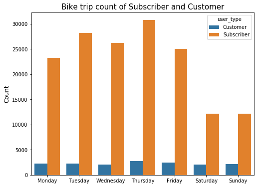

## Riding Duration for Customer and Subscriber

> Faceting for duration_min of customers and subscribers histogram, The graph shows that most of customers are riding between 8-12 minutes, and most subscribers riding between 5-10 minutes.

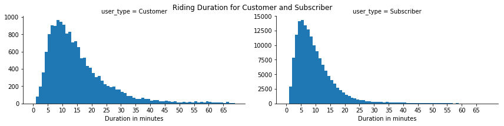

## Count of customers rides in February

> Notice that 30-39 group is the most consistently bike-riders in each day. 20-29 group comes as second, and some days 20-29 group surpassed 30-39.

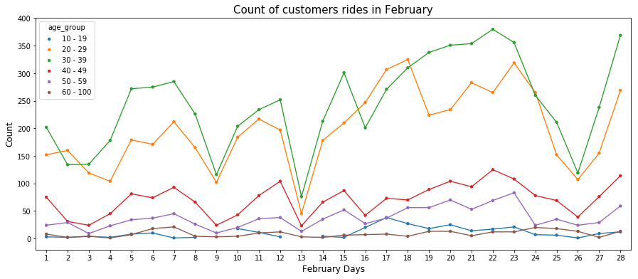

## Customers and Subscribers duration during weekdays

> This visual shows us that the customers bike-riding duration lasted longer than subscribers in every day with at least +2

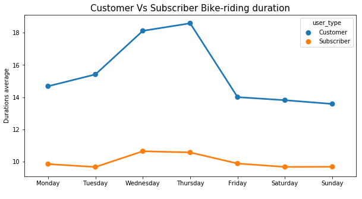

## Heatmap of Age vs. Duration in minutes

> This heatmap shows us that there is a high density in the area of riders with an age between 25-35 and their duration of riding is between 5-15 minutes.

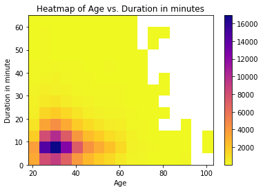